{% raw %}

{% endraw %} {% raw %}

{% endraw %} {% raw %}

```python
from fastai.vision.all import *
```

{% endraw %} {% raw %}

`reduce_loss`[[source]](https://github.com/fastai/fastai/tree/master/fastai/callback/mixup.py#L15)

> `reduce_loss`(**`loss`**:`Tensor`, **`reduction`**:`str`=*`'mean'`*)

Reduce the loss based on `reduction`

|  | Type | Default | Details |
| --- | --- | --- | --- |
| **`loss`** | `Tensor` |  | *No Content* |
| **`reduction`** | `str` | `mean` | PyTorch loss reduction |

{% endraw %} {% raw %}

{% endraw %} {% raw %}

`class` `MixHandler`[[source]](https://github.com/fastai/fastai/tree/master/fastai/callback/mixup.py#L23)

> `MixHandler`(**`alpha`**:`float`=*`0.5`*) :: `Callback`

A handler class for implementing `MixUp` style scheduling

|  | Type | Default | Details |
| --- | --- | --- | --- |
| **`alpha`** | `float` | `0.5` | Determine `Beta` distribution in range (0.,inf] |

{% endraw %} {% raw %}

{% endraw %}

Most `Mix` variants will perform the data augmentation on the batch, so to implement your `Mix` you should adjust the `before_batch` event with however your training regiment requires. Also if a different loss function is needed, you should adjust the `lf` as well. `alpha` is passed to `Beta` to create a sampler.

{% raw %}

`class` `MixUp`[[source]](https://github.com/fastai/fastai/tree/master/fastai/callback/mixup.py#L56)

> `MixUp`(**`alpha`**:`float`=*`0.4`*) :: `MixHandler`

Implementation of https://arxiv.org/abs/1710.09412

|  | Type | Default | Details |
| --- | --- | --- | --- |
| **`alpha`** | `float` | `0.4` | Determine `Beta` distribution in range (0.,inf] |

{% endraw %} {% raw %}

{% endraw %}

This is a modified implementation of mixup that will always blend at least 50% of the original image. The original paper calls for a Beta distribution which is passed the same value of alpha for each position in the loss function (alpha = beta = #). Unlike the original paper, this implementation of mixup selects the max of lambda which means that if the value that is sampled as lambda is less than 0.5 (i.e the original image would be <50% represented, 1-lambda is used instead.

The blending of two images is determined by `alpha`.

$alpha=1.$:

- All values between 0 and 1 have an equal chance of being sampled.
- Any amount of mixing between the two images is possible

$alpha<1.$:

- The values closer to 0 and 1 become more likely to be sampled than the values near 0.5.
- It is more likely that one of the images will be selected with a slight amount of the other image.

$alpha>1.$:

- The values closer to 0.5 become more likely than the numbers close to 0 or 1.
- It is more likely that the images will be blended evenly.

First we'll look at a very minimalistic example to show how our data is being generated with the `PETS` dataset:

{% raw %}

```python
path = untar_data(URLs.PETS)
pat        = r'([^/]+)_\d+.*$'
fnames     = get_image_files(path/'images')
item_tfms  = [Resize(256, method='crop')]
batch_tfms = [*aug_transforms(size=224), Normalize.from_stats(*imagenet_stats)]
dls = ImageDataLoaders.from_name_re(path, fnames, pat, bs=64, item_tfms=item_tfms,
                                    batch_tfms=batch_tfms)
```

{% endraw %}

We can examine the results of our `Callback` by grabbing our data during `fit` at `before_batch` like so:

{% raw %}

| epoch | train_loss | valid_loss | time |
| --- | --- | --- | --- |
| 0 | 00:00 |  |  |

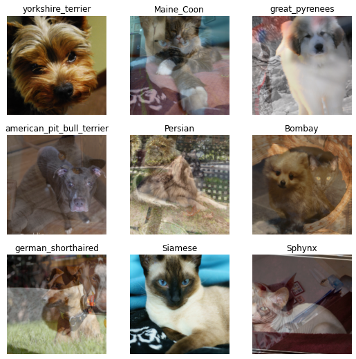

```python
mixup = MixUp(1.)
with Learner(dls, nn.Linear(3,4), loss_func=CrossEntropyLossFlat(), cbs=mixup) as learn:
    learn.epoch,learn.training = 0,True
    learn.dl = dls.train
    b = dls.one_batch()
    learn._split(b)
    learn('before_train')
    learn('before_batch')

_,axs = plt.subplots(3,3, figsize=(9,9))
dls.show_batch(b=(mixup.x,mixup.y), ctxs=axs.flatten())
```

{% endraw %}

We can see that every so often an image gets "mixed" with another.

How do we train? You can pass the `Callback` either to `Learner` directly or to `cbs` in your fit function:

{% raw %}

```python
learn = vision_learner(dls, resnet18, loss_func=CrossEntropyLossFlat(), metrics=[error_rate])
learn.fit_one_cycle(1, cbs=mixup)
```

| epoch | train_loss | valid_loss | error_rate | time |
| --- | --- | --- | --- | --- |
| 0 | 2.041960 | 0.495492 | 0.162382 | 00:12 |

{% endraw %} {% raw %}

`class` `CutMix`[[source]](https://github.com/fastai/fastai/tree/master/fastai/callback/mixup.py#L78)

> `CutMix`(**`alpha`**:`float`=*`1.0`*) :: `MixHandler`

Implementation of https://arxiv.org/abs/1905.04899

|  | Type | Default | Details |
| --- | --- | --- | --- |
| **`alpha`** | `float` | `1.0` | Determine `Beta` distribution in range (0.,inf] |

{% endraw %} {% raw %}

{% endraw %}

Similar to `MixUp`, `CutMix` will cut a random box out of two images and swap them together. We can look at a few examples below:

{% raw %}

| epoch | train_loss | valid_loss | time |
| --- | --- | --- | --- |
| 0 | 00:00 |  |  |

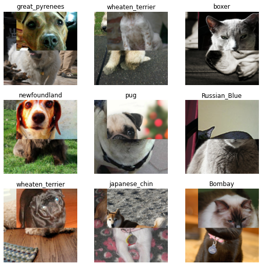

```python
cutmix = CutMix(1.)
with Learner(dls, nn.Linear(3,4), loss_func=CrossEntropyLossFlat(), cbs=cutmix) as learn:
    learn.epoch,learn.training = 0,True
    learn.dl = dls.train
    b = dls.one_batch()
    learn._split(b)
    learn('before_train')
    learn('before_batch')

_,axs = plt.subplots(3,3, figsize=(9,9))
dls.show_batch(b=(cutmix.x,cutmix.y), ctxs=axs.flatten())
```

{% endraw %}

We train with it in the exact same way as well

{% raw %}

```python
learn = vision_learner(dls, resnet18, loss_func=CrossEntropyLossFlat(), metrics=[accuracy, error_rate])
learn.fit_one_cycle(1, cbs=cutmix)
```

| epoch | train_loss | valid_loss | accuracy | error_rate | time |
| --- | --- | --- | --- | --- | --- |
| 0 | 3.440883 | 0.793059 | 0.769959 | 0.230041 | 00:12 |

{% endraw %}